# **TELECOM CHURN PREDICTION**

#### **This report will list down all my approaches and outputs for the codes and algorithms tried throughout the project.**

### `Approach 1: Random Forest on Entire data`

```r
df <- read.csv("C:/Users/mukes_000/Downloads/Telecom_Churn_Data/Telecom Churn Data/Data.csv")
df$target=as.factor(df$target)
set.seed(134);x=sample(1:25000,0.8*25000)
train_data_num=df[x,]
test_data_num=df[-x,]
library(randomForest)
ml=randomForest(target~.,data=train_data_num)
p_r_train=predict(ml,train_data_num)
p_r_test <- predict(ml,test_data_num)
```

> Confusion matrix on train data

```
         Actual
Predicted     0     1
        0 13664     0
        1     0  6336
```

> Confusion matrix on test data

```
         Actual
Predicted    0    1
        0 3053  608
        1  366  973
```

> Using a custom function to find accuracy and other metrics

```r
metrics=function(actual,predicted)
{
  actual=as.numeric(as.character(actual));predicted=as.numeric(as.character(predicted))
  accuracy=sum(!xor(actual, predicted))/length(actual);print(paste("accuracy: ", accuracy))
  recall=sum(predicted & actual) / sum(actual);print(paste("recall: ",recall))
  p=sum(predicted & actual) / sum(predicted);print(paste("precision: ",p))
}
```

**`Metrics on train data`**

```
[1] "accuracy:  1"
[1] "recall:  1"
[1] "precision:  1"
```

**`Metrics on test data`**

```
[1] "accuracy:  0.8052"
[1] "recall:  0.615433270082226"
[1] "precision:  0.726661687826736"
```

### `Approach 2: Logistic regression on Entire data`

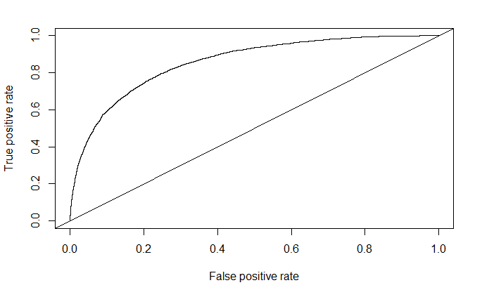

```r
df <- read.csv("C:/Users/mukes_000/Downloads/Telecom_Churn_Data/Telecom Churn Data/Data.csv")
df$target=as.factor(df$target)
set.seed(134);x=sample(1:nrow(df),0.8*nrow(df))
train_data_num=df[x,]
test_data_num=df[-x,]
log_model=glm(target~.,data=train_data_num,family=binomial)
p_train <- predict(log_model,train_data_num, type="response")
p_r_train=(ifelse(p_train>0.3,1,0))
p_test <- predict(log_model,test_data_num, type="response")
p_r_test=(ifelse(p_test>0.3,1,0))
pr <- prediction(p_train, train_data_num$target)
prf <- performance(pr, measure = "tpr", x.measure = "fpr")
auc <- performance(pr, measure = "auc")
auc <- auc@y.values[[1]]
plot(prf)
abline(a=0, b= 1)
```

### The AUC obtained is 0.8397546

> Confusion matrix on train data

```
         Actual
Predicted     0     1
        0 10434  1368
        1  3230  4968
```

> Confusion matrix on test data

```
      Predicted
Actual    0    1
     0 2572  847
     1  317 1264
```

**`Metrics on train data`**

```
[1] "accuracy:  0.7701"
[1] "recall:  0.784090909090909"
[1] "precision:  0.606001463771652"
```

**`Metrics on test data`**

```
[1] "accuracy:  0.7672"
[1] "recall:  0.799493991144845"
[1] "precision:  0.598768356229275"
```

### `Approach 3: Logistic regression on PCA components`

Here we are using attributes with only continuous values, as the discrete values when normalized can cause issues while calculating the principal components.

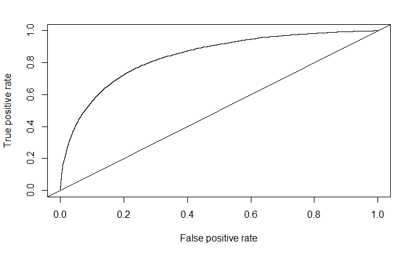

```r
df <- read.csv("C:/Users/mukes_000/Downloads/Telecom_Churn_Data/Telecom Churn Data/Data.csv")
numr_attr=sapply(df,is.integer)
numeric_data=df[,!numr_attr]
set.seed(134);x=sample(1:nrow(df),0.8*nrow(df))
train_data_num=numeric_data[x,]
prin_comp=prcomp(train_data_num,scale. = T)
train_data=as.data.frame(prin_comp$x[,1:12])##Taking 12 PCA components as they explain close to 80% variance
train_data$target=as.factor(df$target[x])
test_data_num=numeric_data[-x,]
test_data=as.data.frame(predict(prin_comp,test_data_num)[,1:12])
test_data$target=as.factor(df$target[-x])
log_model=glm(target~.,data=train_data,family=binomial)
p_train <- predict(log_model,train_data, type="response")
p_r_train=(ifelse(p_train>0.3,1,0))
p_test <- predict(log_model,test_data, type="response")
p_r_test=(ifelse(p_test>0.3,1,0))
pr <- prediction(p_train, train_data$target)
prf <- performance(pr, measure = "tpr", x.measure = "fpr")
auc <- performance(pr, measure = "auc")
auc <- auc@y.values[[1]]
plot(prf)
abline(a=0, b= 1)
```

> Confusion matrix on train data

```
         Actual
Predicted     0     1
        0 10320  1453
        1  3344  4883
```

> Confusion matrix on test data

```
      Predicted
Actual    0    1
     0 2557  862
     1  327 1254
```

**`Metrics on train data`**

```
[1] "accuracy:  0.76015"
[1] "recall:  0.770675505050505"
[1] "precision:  0.593533487297921"
```

**`Metrics on test data`**

```
[1] "accuracy:  0.7622"
[1] "recall:  0.793168880455408"
[1] "precision:  0.592627599243856"
```

#### Conclusion for both logistic models: The PCA model is a simpler model as compared to the overall model and it deals well with multicollinear attributes but is not explicable and loses explainability.

### `Approach 4: Gradient boosting on Entire data`

```r
library(xgboost)
df <- read.csv("C:/Users/mukes_000/Downloads/Telecom_Churn_Data/Telecom Churn Data/Data.csv")
set.seed(134);x=sample(1:nrow(df),0.8*nrow(df))
tr=df[x,]
tst=df[-x,]
tr_label=tr$target
tr$target=NULL
xgb_tr=xgb.DMatrix(as.matrix(tr),label=tr_label)
tst_label=tst$target
tst$target=NULL
xgb_tst=xgb.DMatrix(as.matrix(tst),label=tst_label)
xgb_ml=xgb.train(params=list("eta"=0.005,"subsample"=0.8,"colsample_bytree"=0.6, "max_depth"=5,
                             "objective"="binary:logistic"),data=xgb_tr,nrounds = 1200)
pred_xgb_tr=predict(xgb_ml,xgb_tr); pred_xgb_tr=(ifelse(pred_xgb_tr>0.3,1,0))
pred_xgb_tst=predict(xgb_ml,xgb_tst);pred_xgb_tst=(ifelse(pred_xgb_tst>0.3,1,0))
```

> Confusion matrix on train data

```
    Actual
pred     0     1
   0 10918  1070
   1  2746  5266
```

> Confusion matrix on test data

```
    Actual
pred    0    1
   0 2616  318
   1  803 1263
```

**`Metrics on train data`**

```
[1] "accuracy:  0.8092"
[1] "recall:  0.831123737373737"
[1] "precision:  0.657264103844234"
```

**`Metrics on test data`**

```
[1] "accuracy:  0.7758"
[1] "recall:  0.798861480075901"
[1] "precision:  0.611326234269119"
```